# Homework 4

Lena Hicks

May 20, 2023

## Set Up

```r
#loading in all necessary packages for intented uses
library(tidyverse)
library(lterdatasampler)
library(here)
library(performance)
library(broom)
library(ggeffects)
library(ggmice)
library(janitor)
library(huxtable)
```

### Loading data in

```r
#loading in data, located using here package
fish <- read_csv(
  here("data", "ntl6_v12.csv"))
```

### Filtering data

```r
#filtering data so as specific to our research question, and cleaning columns up
trout_perch <- fish %>%
  clean_names() %>%
  filter( spname == "TROUTPERCH")
```

# Problem 1

1. For the null, Trout Perch fish length does not predict the weight of the fish over all years. Alternatively, Trout Perch fish length does predict fish weight over all the sample years. Mathmatical: H0: β1 = 0 [there is no linear relationship between trout perch length and weight] HA: β1 =/= 0 [there is a linear relationship between trout perch length and weight]

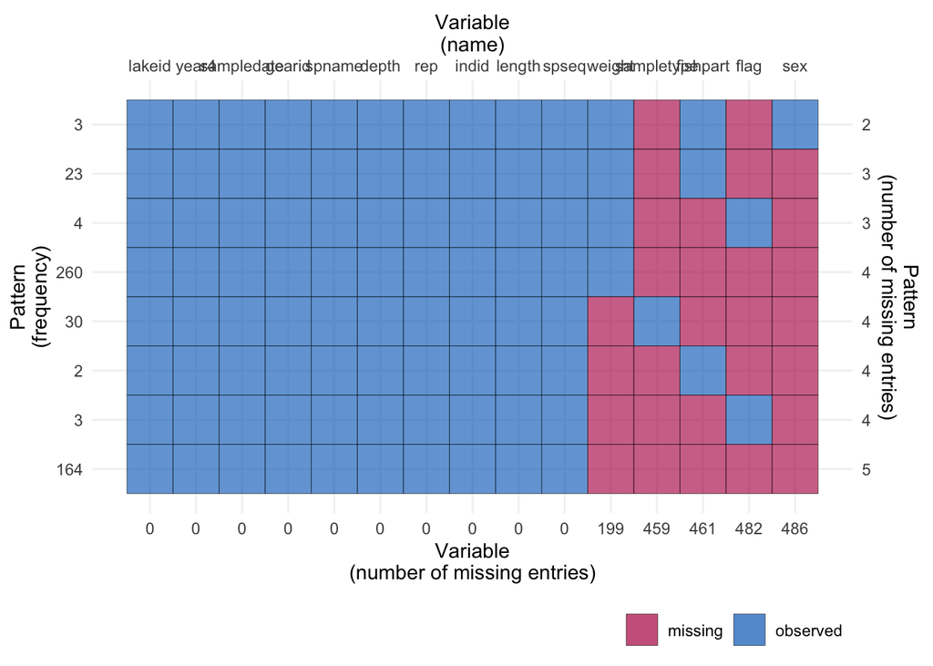

```r
plot_pattern(trout_perch)
```

Of the missing data from this data set, there are 199 missing entries from the Weight column, which is a distinct amount of missing entries for one of the main variables we are interested in. While interpreting the data to come, it must be noted that it will not be an entirely accurate view of the relationship between length and weight with so many missing entries from weight.

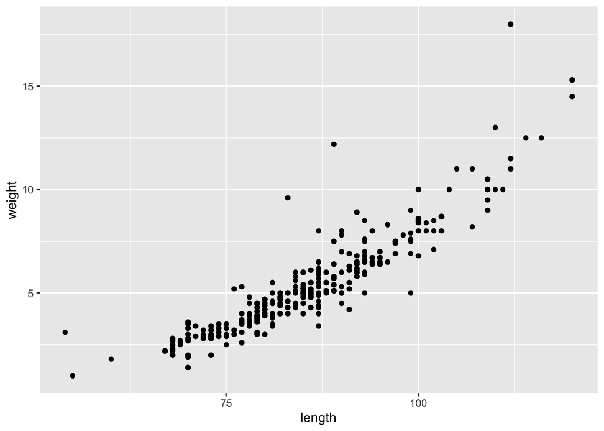

```r
#testing for linear relationship between variables using exploratory data visualization; looks linear!
ggplot(data = trout_perch, aes(x = length, y = weight)) +
  geom_point()
```

```r
#running our test of looking at the linear model for the response, weight, to the predictor, length
trout_model <- lm(formula = weight ~ length, data = trout_perch)

#looking at the resulting linear model
trout_model
```

```
##
## Call:
## lm(formula = weight ~ length, data = trout_perch)
##
## Coefficients:
## (Intercept)       length
##    -11.7025       0.1999
```

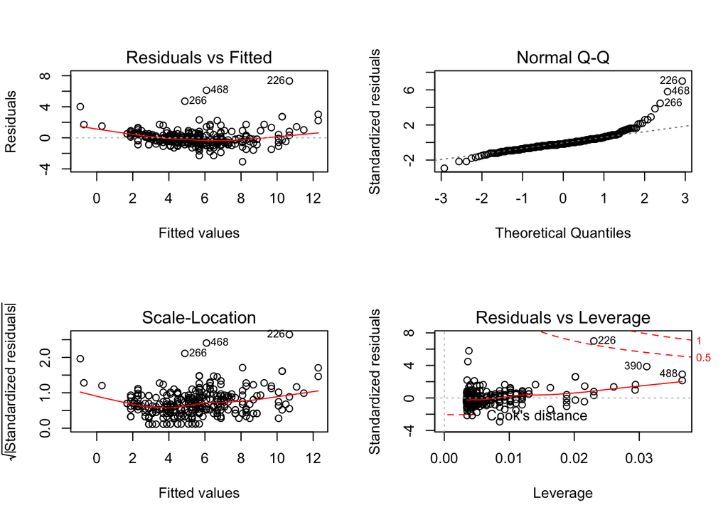

```r
#creating the diagnostic plots in a 2x2 format plot grid based off the linear model to check assumptions
par(mfrow = c(2, 2))
plot(trout_model)
```